# OLS in R

Refresher: We’re wondering how `yrs.since.phd` is associated with `salary` in the `Salaries` dataset from the `car` library. If you haven’t already. load the necessary libraries, load this dataset, and convert it to a `data.table`. Also load the `ggplot2` library, we’ll need it later.

## Running a Regression

Let’s take a look at our dataset:

```r
print(Salaries)
```

```
##          rank discipline yrs.since.phd yrs.service  sex salary
##   1:     Prof          B            19          18 Male 139750
##   2:     Prof          B            20          16 Male 173200
##   3: AsstProf          B             4           3 Male  79750
##   4:     Prof          B            45          39 Male 115000
##   5:     Prof          B            40          41 Male 141500
##  ---
## 393:     Prof          A            33          30 Male 103106
## 394:     Prof          A            31          19 Male 150564
## 395:     Prof          A            42          25 Male 101738
## 396:     Prof          A            25          15 Male  95329
## 397: AsstProf          A             8           4 Male  81035
```

Again, we want to regress `yrs.since.phd` on `salary`. The function that you use to run a linear regression is called `lm()`, for “linear model”. The two main arguments that `lm()` needs are a `formula` argument *specifying* the regression, and a `data` argument telling it what dataset to work with.

### Specifying the model with `formula`

Remember formulas? We used them to reshape datasets and to facet plots. They’re the ones with the `~`. Also, remember how last lecture we wrote that equation that *specified* our formula? The one that had the variables we wanted to include, but didn’t have values for $\beta_0$ or $\beta_1$ yet:

$$salary = \beta_0 + \beta_1yrs.since.phd + \varepsilon$$

In R, we use `formula`s to specify our model exactly the same way. A regression formula in R will always be of the format:  
`y_variable ~ x_variable_1 + x_variable_2 + x_variable_3...`

Where `y_variable`, `x_variable_1`, etc. are all column names in your dataset. **There will never be more than one variable on the left side of the `~`**: You can only regress on one outcome variable at once. Today, we’re only going to have one x variable to the right side of the `~`, but in theory you could have many: we’ll get to that next week.

Again, remember, **outcome variable goes to the left, predictor variable(s) go to the right**.

The formula for the regression we want to run, then, is `salary ~ yrs.since.phd`.

Notice that this is considerably more parsimonious than the big honking equation we wrote above– it doesn’t have any $\beta$s in it, and we haven’t written out either our error term $\varepsilon$ or our intercept term $\beta_0$. This is because a good regression will *always* include an intercept, and *must* by definition allow some room for error, so both of these terms are generated automatically by the `lm` function. We’ll still get an output for the estimated value of our $\beta_0$ even though we didn’t write out an intercept term.

Similarly, we don’t have to write out any $\beta$s explicity because there’s the assumption that, if you’re including something in the model, you *must* want to associate a $\beta$ with it. So, what the `lm` function interprets when it sees `salary ~ yrs.since.phd` is “Run a linear regression with an outcome variable of `salary` and a predictor variable of `yrs.since.phd`. Return $\beta$ values both for `yrs.since.phd` and for the intercept.”

### Pointing to data with `data`

The `data` argument to `lm` is easy, it’s just the name of your dataset.

### Putting it Together

It’s finally time to run our first regression. The `formula` argument comes before the `data` one, so we write:

```r
regression_output <- lm(salary ~ yrs.since.phd, data=Salaries)
print(regression_output)
```

```
##
## Call:
## lm(formula = salary ~ yrs.since.phd, data = Salaries)
##
## Coefficients:
##   (Intercept)  yrs.since.phd
##       91718.7          985.3
```

And there we have it! This linear regression predicts an intercept value ($\beta_0$) of $91,718.70, and a coefficient on `yrs.since.phd` (i.e. a $\beta_1$) of $985.30. Remember how to interpret these regression outputs from our first regression lecture?

**“A professor with zero years since his/her Ph.D is expected to make $91,718.70, and every additional year since Ph.D adds $985.30 to that profesor’s expected salary.”**

Just printing out the output of a regression gives you the bare minimum of information about it: what regression you ran, and what your $\beta$ values were. You can get much richer information by calling `summary` on your regression output, but it can be kind of hard to interpret. Let’s review it below.

## Interpreting Regression Output

Running `print(regression_output)` gave us results that were easy to interpret, but which didn’t contain much information. Let’s try this instead:

```r
summary(regression_output)
```

```
##
## Call:
## lm(formula = salary ~ yrs.since.phd, data = Salaries)
##
## Residuals:
##    Min     1Q Median     3Q    Max
## -84171 -19432  -2858  16086 102383
##
## Coefficients:
##               Estimate Std. Error t value Pr(>|t|)
## (Intercept)    91718.7     2765.8  33.162   <2e-16 ***
## yrs.since.phd    985.3      107.4   9.177   <2e-16 ***
## ---
## Signif. codes:  0 '***' 0.001 '**' 0.01 '*' 0.05 '.' 0.1 ' ' 1
##
## Residual standard error: 27530 on 395 degrees of freedom
## Multiple R-squared:  0.1758, Adjusted R-squared:  0.1737
## F-statistic: 84.23 on 1 and 395 DF,  p-value: < 2.2e-16
```

Whoa! That’s a lot more information! Let’s walk through each section at a time.

### `Call`

This is the same as when you use your `print` command– just an echo of specifically what code you ran to generate this regression output. Useful for reference.

### `Coefficients`

This is the main section of interest for us– it tells us about our $\beta$ values, their standard errors, and their p-values. The leftmost column is a list of all the variables that were included in the regression. Again, notice that even though we didn’t specify an Intercept term, one was generated for us automatically.

The `Estimate` column gives us the estimated $\beta$, or coefficient, value for that variable. This is analogous to the simple output we see when we run `print(regression_output)`.

The `Std. Error` column gives us the estimated standard errors for each variable. Thinking back to the distributions we made last time, we see that the standard error for the `yrs.since.phd` variable is pretty small, meaning that there’s not much uncertainty about the value of this coefficient.

The `t value` column is used in the calculation of p-values, beyond the scope of this class.

The confusingly-named `Pr(>|t|)` column gives us p-values for each variable. The asterisks next to them, as explained in the `Signif. codes` section underneath the table, indicates how statistically significant each coefficient is. For very small numbers, p-values are specified in *scientific notation*. So `2e-16` means $2*10^{-16}$, or $0.0000000000000002$. That’s really, really small! Way below $0.05$, the classic cutoff for statistical significance. You’ll see the `<2e-16` p-value often: it’s what R uses when the p-value is to small to represent any other way.

### Others

The final three lines of this output give us some useful statistics for the regression as a whole. The only one of these I want you to pay attention to is the Adjusted R-squared value. R-squared, along with p-value, is another common statistic for assessing the goodness-of-fit of your model. the R-squared value will tell you *how much variation in your outcome variable can be predicted by your predictor variable*. If the data were a straight line, the R-squared value would be 1. If the data were random noise, R-squared would be close to zero (or could, in some cases, even be negative). Here we have an adjusted R-squared of 0.1737, meaning that only about 17% of the variance in `salary` can be explained by `yrs.since.phd`.

### Some Things to Note About Regression Outputs:

- The last line of the regression output specifies a p-value for the regression as a whole. **IGNORE THIS VALUE**. We’re only interested in p-values in the context of specific variables.
- The regression gives standard error and p-values for the Intercept term, but we rarely or never report these, as they don’t have much meaning. For the intercept, we’re really only interested in the `Estimate` value. For all other variables, however, you always want to report the mean (“Estimate”) value, the SE, *and* the p-value.
- The `Estimate` values are always in units of whatever the *outcome* variable is in units of. So everything in the `Estimate` column is in units of dollars, because the outcome variable `salary` is in units of dollars.

## Predicting From Regression Outputs

Remember our motivations for statistical analysis: inference and prediction. The regression outputs as they stand tell us everything we need to know about inference, but what about prediction? How do we guess what a person’s salary is, based on their years since Ph.D? For that, we use the `predict` function.

`predict` by default takes only one argument– the output of the linear regression you run. So, if we ran `predict(regression_output)` we would get a vector of predicted salary values for each professor in our dataset. It’s common to save this as a column in the dataset itself:

```r
Salaries[, predicted_salary:= predict(regression_output)]
```

```
##          rank discipline yrs.since.phd yrs.service  sex salary
##   1:     Prof          B            19          18 Male 139750
##   2:     Prof          B            20          16 Male 173200
##   3: AsstProf          B             4           3 Male  79750
##   4:     Prof          B            45          39 Male 115000
##   5:     Prof          B            40          41 Male 141500
##  ---
## 393:     Prof          A            33          30 Male 103106
## 394:     Prof          A            31          19 Male 150564
## 395:     Prof          A            42          25 Male 101738
## 396:     Prof          A            25          15 Male  95329
## 397: AsstProf          A             8           4 Male  81035
##      predicted_salary
##   1:        110440.19
##   2:        111425.53
##   3:         95660.05
##   4:        136059.08
##   5:        131132.37
##  ---
## 393:        124234.98
## 394:        122264.29
## 395:        133103.05
## 396:        116352.24
## 397:         99601.42
```

See? Now we have a new column in our dataset specifying our *predicted* salaries. All that the `predict` function does is the arithmetic we did by hand last lecture: If $\beta_0$ is $91,718.70, $\beta_1$ is $985.30, and the first professor in the dataset has 19 years since his Ph.D, then his predicted salary is $91,718.70 + 985.30*19$, or $110,440.

If, instead, we want to predict salaries for *new* professors who weren’t included in the dataset, we can use the argument `newdata` to `predict` to accomplish that. First, we need to make a new dataset of professors for whom we want to predict salaries. It *must* include columns with *exactly the same names* as all our *predictor* variables. So, in this case, it *must* have a column called “yrs.since.phd”, and any other columns are optional. I’ll make a small dataset that just lists some ID value for each professor, and their yrs.since.phd:

```r
new_salaries <- data.table(prof.id=1:5,
                           yrs.since.phd=c(13, 25, 3, 27, 9))
print(new_salaries)
```

```
##    prof.id yrs.since.phd
## 1:       1            13
## 2:       2            25
## 3:       3             3
## 4:       4            27
## 5:       5             9
```

Great! Now to predict salaries for these individuals I just need to do:

```r
predict(regression_output, newdata=new_salaries)
```

```
##         1         2         3         4         5
## 104528.13 116352.24  94674.71 118322.92 100586.76
```

Or, to add a new column to this dataset:

```r
new_salaries[, predicted_salary:= predict(regression_output, newdata=new_salaries)]
```

```
##    prof.id yrs.since.phd predicted_salary
## 1:       1            13        104528.13
## 2:       2            25        116352.24
## 3:       3             3         94674.71
## 4:       4            27        118322.92
## 5:       5             9        100586.76
```

## Plotting Regression Outputs

In the `ggplot` section, we learned a quick and dirty shortcut to plotting a best-fit line using `geom_smooth`. But if we go through the trouble of actually running a regression, we should plot the actual regression outputs, not the `geom_smooth`-ed line. Now that `predict` has already given us a new column in our dataset, we can accomplish this easily: just replace the `geom_smooth` geom with a `geom_line` plotting the `predicted_salary` column. Pay close attention to where I put which aesthetics:

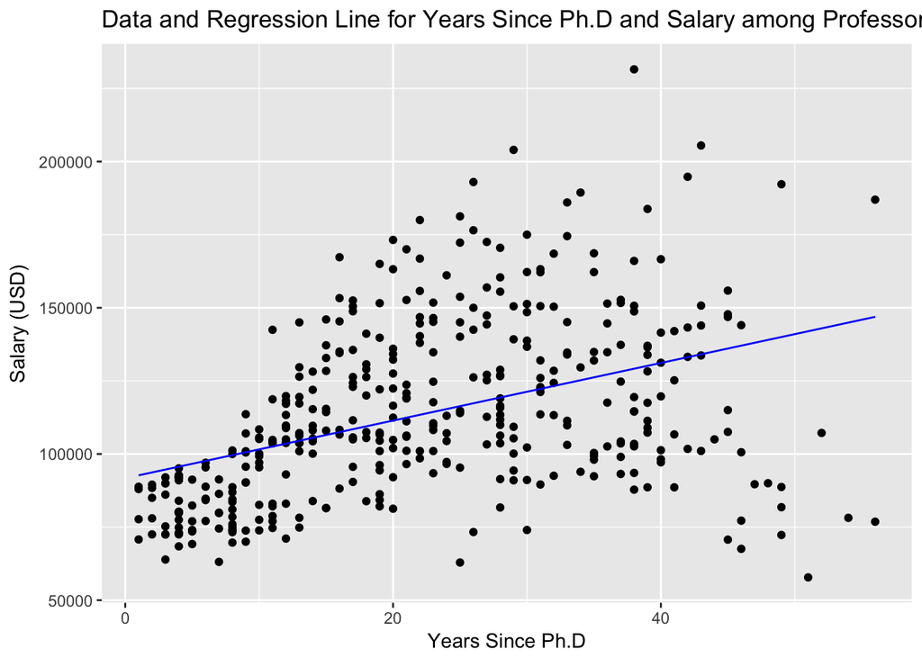

```r
ggplot(Salaries, aes(x=yrs.since.phd)) +
  geom_point(aes(y=salary)) +
  geom_line(aes(y=predicted_salary), color="blue") +
  labs(title="Data and Regression Line for Years Since Ph.D and Salary among Professors",
       x="Years Since Ph.D",
       y="Salary (USD)")
```

## Another Example: Cereal

Let’s load and clean the `UScereal` dataset again.

```r
# load MASS library and UScereal dataset
library(MASS)
data(UScereal)

# save the names of cereals as an actual row, instead of an index value
UScereal$cereal_name <- rownames(UScereal)

# convert to a data.table
UScereal <- data.table(UScereal)

# clean up some column values
UScereal[, shelf:=NULL] # we won't need that column
UScereal[, sodium:= sodium/1000] # this converts the units of the "sodium" column from milligrams to grams
UScereal[, potassium:=potassium/1000] # converts units of the "potassium" column from milligrams to grams

# rearrange the column order
setcolorder(UScereal, c("cereal_name", "mfr", "vitamins", "calories", "protein", "fat", "sodium", "fibre", "carbo", "sugars", "potassium"))
```

Say I’m interested in analyzing whether or not more fat per serving of a cereal corresponds to more calories per serving. I want `calories` to be my outcome variable, and `fat` to be my predictor variable. How would I specify my regression? Try it on your own before looking at the answer.

…

…

Ready?

The code to run this regression is:

```r
cereal_output <- lm(calories ~ fat, data=UScereal)
summary(cereal_output)
```

```
##
## Call:
## lm(formula = calories ~ fat, data = UScereal)
##
## Residuals:
##    Min     1Q Median     3Q    Max
## -67.60 -29.96  -7.04  16.73 322.40
##
## Coefficients:
##             Estimate Std. Error t value Pr(>|t|)
## (Intercept)  117.599      8.350  14.084  < 2e-16 ***
## fat           22.361      3.854   5.803 2.29e-07 ***
## ---
## Signif. codes:  0 '***' 0.001 '**' 0.01 '*' 0.05 '.' 0.1 ' ' 1
##
## Residual standard error: 50.78 on 63 degrees of freedom
## Multiple R-squared:  0.3483, Adjusted R-squared:  0.338
## F-statistic: 33.67 on 1 and 63 DF,  p-value: 2.292e-07
```

Using the `Salaries` example above as a guide, see if you can determine:

- What the regression coefficients are for both the intercept and the `fat` variable.
- What the standard error and p-value is for the `fat` variable.
- What those regression coefficients *mean*–see if you can put them in a sentence, like the one in bold above for `Salaries`.
- What the adjusted R-squared is for this regression.

I’ll give you the answer to the third question:

**“A cereal with zero grams of fat is expected to have 117.6 calories,, and every additional gram of fat adds 22.36 to that cereal’s expected caloric value.”**

Let’s plot this regression! Remember, we can create a new column in the dataset with predicted values using `predict`:

```r
UScereal[, predicted_calories:= predict(cereal_output)]
```

```r
UScereal[, predicted_calories:= predict(cereal_output)]

ggplot(UScereal, aes(x=fat)) +
  geom_point(aes(y=calories)) +
  geom_line(aes(y=predicted_calories), color="blue") +
  labs(title = "Data and Regression Line for Fat and Calories among US Breakfast Cereals",
       x="Fat (g per Serving)",
       y="Calories per Serving")
```

[output not shown]

We’ve just scratched the surface of regressions here– next time, we’ll dig a little deeper into assumptions of linearity and correct model specifications, and learn how to add new variables to regressions.